# Exploratory Data Analysis

> *Coming up with features is difficult, time-consuming, requires expert knowledge. 'Applied machine learning' is basically feature engineering*. - Andrew Ng, Founder and CEO of Landing AI

```python
# Specifies the event name and the date of the event
events = {
    "germanwings-crash": datetime(2015, 3, 24),
    "ferguson": datetime(2014, 8, 9),
    "ottawashooting": datetime(2014, 10, 22),
    "charliehebdo": datetime(2015, 1, 7),
    "sydneysiege": datetime(2014, 12, 15)
}

# Combine all PHEME events into one dataframe
tweets = pd.concat([ fetch_tweets(name) for name in events ])
tweets[["is_source_tweet","is_rumor"]] = tweets[["is_source_tweet", "is_rumor"]].astype(bool)

# So what does this data look like anyway?
tweets.describe()
```

|  | tweet_length | symbol_count | user_mentions | urls_count | media_count | hashtags_count | retweet_count | favorite_count | mentions_count | is_truncated | ... | sentimentscore | Noun | Verb | Adjective | Pronoun | FirstPersonPronoun | SecondPersonPronoun | ThirdPersonPronoun | Adverb | has_url_in_text |
| --- | --- | --- | --- | --- | --- | --- | --- | --- | --- | --- | --- | --- | --- | --- | --- | --- | --- | --- | --- | --- | --- |
| count | 103212.000000 | 103212.000000 | 103212.000000 | 103212.000000 | 103212.000000 | 103212.000000 | 103212.000000 | 103212.000000 | 103212.000000 | 103212.0 | ... | 103212.000000 | 103212.000000 | 103212.000000 | 103212.000000 | 103212.000000 | 103212.000000 | 103212.000000 | 103212.000000 | 103212.0 | 103212.000000 |
| mean | 96.104038 | 0.000039 | 1.688282 | 0.108563 | 0.091937 | 0.296438 | 26.537593 | 14.766888 | 1.688282 | 0.0 | ... | 0.024750 | 5.756753 | 2.378328 | 0.915378 | 0.665892 | 0.156871 | 0.208348 | 0.400050 | 0.0 | 0.165504 |
| std | 38.136487 | 0.006225 | 1.011805 | 0.323340 | 0.289608 | 0.713807 | 518.063950 | 557.239753 | 1.011805 | 0.0 | ... | 0.298488 | 2.896561 | 1.804487 | 1.019915 | 0.955495 | 0.438892 | 0.531075 | 0.726213 | 0.0 | 0.371637 |
| min | 3.000000 | 0.000000 | 0.000000 | 0.000000 | 0.000000 | 0.000000 | 0.000000 | 0.000000 | 0.000000 | 0.0 | ... | -1.000000 | 0.000000 | 0.000000 | 0.000000 | 0.000000 | 0.000000 | 0.000000 | 0.000000 | 0.0 | 0.000000 |
| 25% | 64.000000 | 0.000000 | 1.000000 | 0.000000 | 0.000000 | 0.000000 | 0.000000 | 0.000000 | 1.000000 | 0.0 | ... | 0.000000 | 4.000000 | 1.000000 | 0.000000 | 0.000000 | 0.000000 | 0.000000 | 0.000000 | 0.0 | 0.000000 |
| 50% | 104.000000 | 0.000000 | 2.000000 | 0.000000 | 0.000000 | 0.000000 | 0.000000 | 0.000000 | 2.000000 | 0.0 | ... | 0.000000 | 6.000000 | 2.000000 | 1.000000 | 0.000000 | 0.000000 | 0.000000 | 0.000000 | 0.0 | 0.000000 |
| 75% | 133.000000 | 0.000000 | 2.000000 | 0.000000 | 0.000000 | 0.000000 | 0.000000 | 1.000000 | 2.000000 | 0.0 | ... | 0.122222 | 8.000000 | 4.000000 | 1.000000 | 1.000000 | 0.000000 | 0.000000 | 1.000000 | 0.0 | 0.000000 |
| max | 187.000000 | 1.000000 | 13.000000 | 5.000000 | 2.000000 | 12.000000 | 99524.000000 | 149783.000000 | 13.000000 | 0.0 | ... | 1.000000 | 26.000000 | 11.000000 | 8.000000 | 11.000000 | 5.000000 | 11.000000 | 7.000000 | 0.0 | 1.000000 |

8 rows × 50 columns

## Violin Plots for Feature Selection

Similar to box-and-whisker plots, a violin plot shows the distribution of quantitive data. Unlike box-and-whisker plots, violin plots show the kernel density estimation of the underlying distribution.

The chart below is divided by one binary categorical variable and grouped by other categorical variables.

```
Text(0.5,1,'Distribution of Feature Values (All News Events)')
```

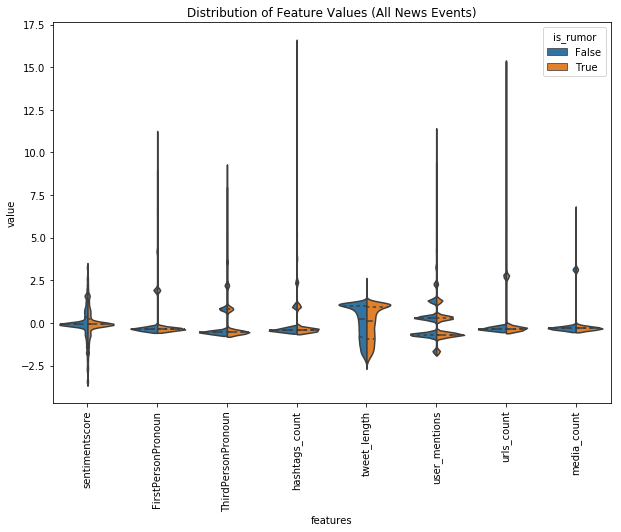

```python
plt.figure(figsize=(10,7))
ax = sns.violinplot(x="features", y="value", hue="is_rumor", data=data, split=True, inner="quart")
plt.xticks(rotation=90)
ax.set_title("Distribution of Feature Values (All News Events)")
```

## Ratio of Rumor to Non-Rumor

Since this project is concerned with classifying rumor and non-rumor tweets, we need to know what the proportion of rumor to non-rumor tweets for each event in the PHEME dataset.

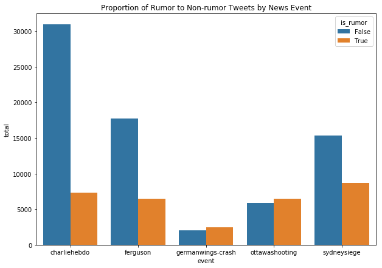

```python
twts_event_rumor = tweets[["event", "tweet_id", "is_rumor"]].groupby(["event", "is_rumor"]).agg(len) \
    .rename(columns={"tweet_id": "total"}).reset_index()
plt.figure(figsize=(10,7))
plt.title("Proportion of Rumor to Non-rumor Tweets by News Event")
ax = sns.barplot(x="event", y="total", hue="is_rumor", data=twts_event_rumor)
```

## Tweet Frequency Over Time

It seems plausable that immediately after a news event, the number of rumor tweets would be greater than the number of non-rumor tweets as the facts start getting sorted out.

In the Germanwings Crash dataset, the first relevant tweet was recorded on March 24, 2015, which is the date of the actual event. Tweets related to the event were collected for the next eight days.

```python
from IPython.display import IFrame
IFrame("html/gw_beeswarm.html", width="100%", height="650")
```

[interactive chart not shown]

If beeswarm plot above won't load, [try this page](https://beta.observablehq.com/@stvkas/twitter-rumors-concerning-the-crash-of-germanwings-flight)

```python
event_dates = tweets.event.map(lambda x: events[x])
created_date = pd.to_datetime(tweets.created * 1e6).dt.round("D")  # Round to date
tweets["delay"] = created_date - event_dates
tweets.delay = tweets.delay.dt.days  # recast time delta to integer to play nice with plots
tweets.delay.describe()
```

```
count    103212.000000
mean          2.229063
std           2.347240
min           0.000000
25%           1.000000
50%           1.000000
75%           3.000000
max          37.000000
Name: delay, dtype: float64
```

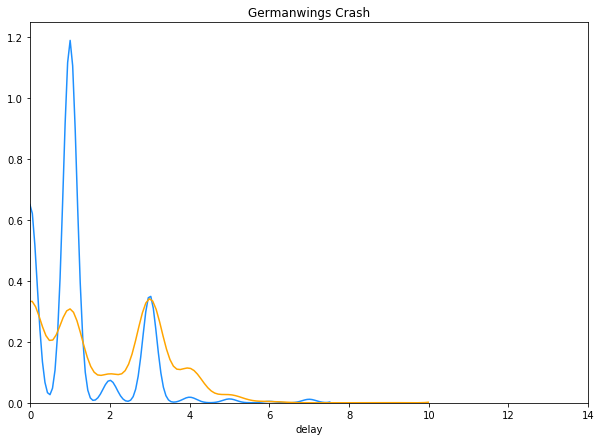

```python
delayPlot("germanwings-crash", "Germanwings Crash")
```

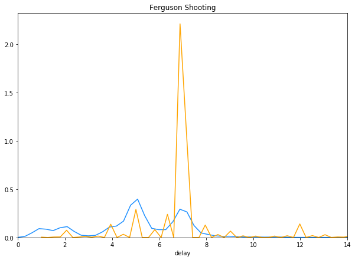

```python
delayPlot("ferguson", "Ferguson Shooting")
```

## Thread Structures

One reason to use a classifier on tweet threads instead of individual tweets is that the conversation constitutes a graph structure where additional features can be extracted that can't when tweets are considered in isolation. For each event, most of the tweets are replies to other tweets.

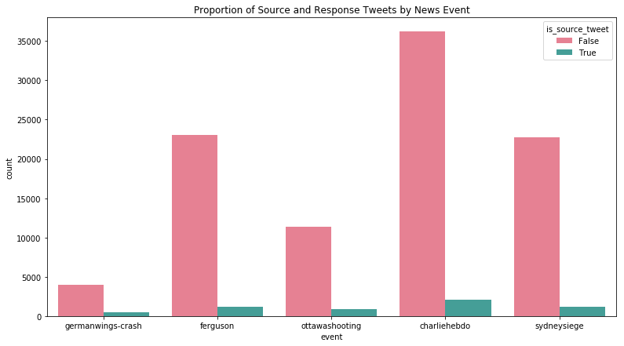

```python
plt.figure(figsize=(13,7))
plt.title("Proportion of Source and Response Tweets by News Event")
ax = sns.countplot(x="event", hue="is_source_tweet", data=tweets, palette="husl")
```

## Exploring the Conversational Network Structure

Tweets in the PHEME dataset are organized into threads, proxies for conversations threads. When one tweet replies to another, it constitutes a thread. Since the vast majority of tweets in this dataset are replies to other tweets, we examined the distribution of *thread length*, the number of individual tweets in a thread.

The variable `thread_lengths` contains the groups tweet data by event and thread, then counts the number of tweets per thread-event group. Each thread should be unique, but grouping by event first makes the code more understandable.

```python
thread_lengths.groupby("event").describe()
```

| event | thread_length count | thread_length mean | thread_length std | thread_length min | thread_length 25% | thread_length 50% | thread_length 75% | thread_length max |
| --- | --- | --- | --- | --- | --- | --- | --- | --- |
| charliehebdo | 2079.0 | 18.406926 | 19.962353 | 1.0 | 8.0 | 15.0 | 22.0 | 346.0 |
| ferguson | 1143.0 | 21.150481 | 26.272486 | 1.0 | 7.0 | 16.0 | 22.0 | 289.0 |
| germanwings-crash | 469.0 | 9.571429 | 9.470699 | 1.0 | 3.0 | 6.0 | 15.0 | 77.0 |
| ottawashooting | 890.0 | 13.802247 | 11.884767 | 1.0 | 6.0 | 11.0 | 19.0 | 108.0 |
| sydneysiege | 1221.0 | 19.652744 | 20.139285 | 1.0 | 9.0 | 17.0 | 22.0 | 342.0 |

```
Text(0.5,1,'Thread Length by Event and Rumor')
```

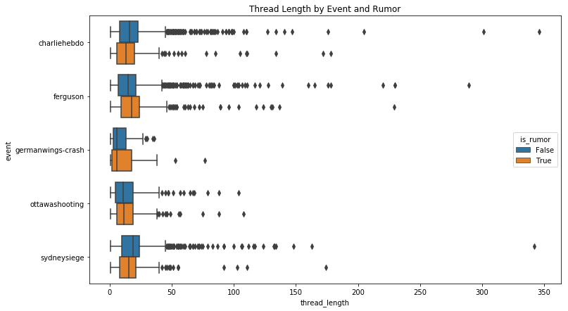

```python
fig, axes = plt.subplots(figsize=(12,7))
ax = sns.boxplot(y="event",
            x="thread_length",
            hue="is_rumor",
            data = thread_lengths)

ax.set_title("Thread Length by Event and Rumor")
```

## Combining Structure and Rumor

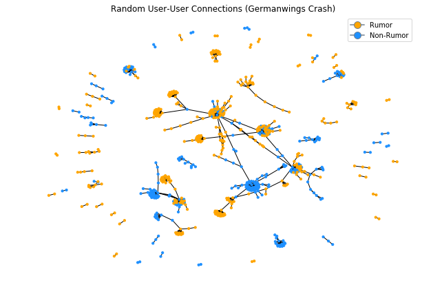

```python
random_threads = list(tweets[tweets.event == "germanwings-crash"][["thread"]].sample(50, random_state=2).thread)
random_connections = tweets[tweets.thread.isin(random_threads)]
graph_connections(random_connections, "Random User-User Connections (Germanwings Crash)")
```

```python
largest_thread = tweets[["thread", "user_id", "event"]] \
    .groupby("thread") \
    .agg({"user_id" : pd.Series.nunique, "event" : max}) \
    .sort_values("user_id", ascending=False) \
    [0:1]

largest_thread
```

| thread | user_id | event |
| --- | --- | --- |
| 499695918547861504 | 125 | ferguson |

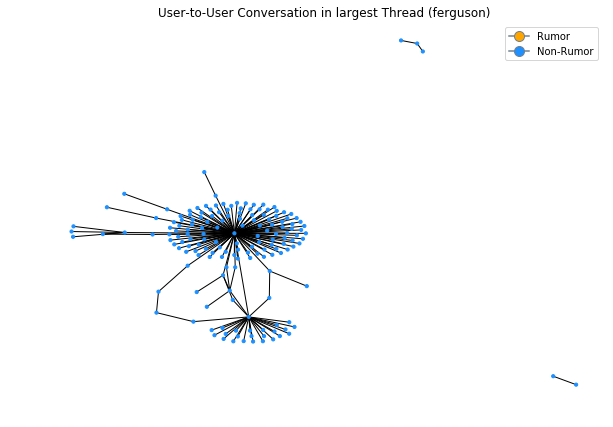

```python
dense_connections = tweets[tweets.thread.isin(list(largest_thread.index))]
graph_connections(dense_connections, "User-to-User Conversation in largest Thread (%s)" % largest_thread.event[0])
```